# Logistic regression

Starting the chapter 3 exercise by ensuring the right working directory and reading in the created data set from the data wrangling exercise and print the variable names. My data set was saved as ‘alc.csv’. The data set includes 382 observations with 35 variables. The observations are from Portuguese students which now will be analysed for their alcohol consumption and to identify which variables are related factors. The variables in question are listed below in the column names, with emphasis on the computed alcohol use “alc_use”, which is the avergae of daily and weekly alcohol consumption ‘(Dalc+Walc)/2’. If this use is higher than 2 than the logical factor “high_use” appears TRUE. This high alcohol usage will be the target variable for the exercise.

```r
getwd()
```

```
## [1] "C:/Users/lonav/Documents/IODS-project"
```

```r
setwd("C:/Users/lonav/Documents/IODS-project")
library(openxlsx)
alc <- read.csv("alc.csv", sep = ",", header = TRUE)
library(dplyr)
colnames(alc)
```

```
##  [1] "school"     "sex"        "age"        "address"    "famsize"
##  [6] "Pstatus"    "Medu"       "Fedu"       "Mjob"       "Fjob"
## [11] "reason"     "nursery"    "internet"   "guardian"   "traveltime"
## [16] "studytime"  "failures"   "schoolsup"  "famsup"     "paid"
## [21] "activities" "higher"     "romantic"   "famrel"     "freetime"
## [26] "goout"      "Dalc"       "Walc"       "health"     "absences"
## [31] "G1"         "G2"         "G3"         "alc_use"    "high_use"
```

```r
glimpse(alc)
```

```
## Observations: 382
## Variables: 35
## $ school     <fct> GP, GP, GP, GP, GP, GP, GP, GP, GP, GP, GP, GP, GP,...
## $ sex        <fct> F, F, F, F, F, M, M, F, M, M, F, F, M, M, M, F, F, ...
## $ age        <int> 18, 17, 15, 15, 16, 16, 16, 17, 15, 15, 15, 15, 15,...
## $ address    <fct> U, U, U, U, U, U, U, U, U, U, U, U, U, U, U, U, U, ...
## $ famsize    <fct> GT3, GT3, LE3, GT3, GT3, LE3, LE3, GT3, LE3, GT3, G...
## $ Pstatus    <fct> A, T, T, T, T, T, T, A, A, T, T, T, T, T, A, T, T, ...
## $ Medu       <int> 4, 1, 1, 4, 3, 4, 2, 4, 3, 3, 4, 2, 4, 4, 2, 4, 4, ...
## $ Fedu       <int> 4, 1, 1, 2, 3, 3, 2, 4, 2, 4, 4, 1, 4, 3, 2, 4, 4, ...
## $ Mjob       <fct> at_home, at_home, at_home, health, other, services,...
## $ Fjob       <fct> teacher, other, other, services, other, other, othe...
## $ reason     <fct> course, course, other, home, home, reputation, home...
## $ nursery    <fct> yes, no, yes, yes, yes, yes, yes, yes, yes, yes, ye...
## $ internet   <fct> no, yes, yes, yes, no, yes, yes, no, yes, yes, yes,...
```

[output cut: 22 more lines]

# Most interesting variables

The variables failures, absences, sex and age are choosen as predictors. The hypotheses are that failures, absences and age increase with alcohol consumption. Due to popular consensus women will have less high alcohol usage than men. Findings: Failures, absences and sex were significant predictors. Age, on the other hand, showed no significant influence on high alcohol usage. Therefore, the hypothesis that failures and absences increase with high alcohol usage can be confirmed but for the impact of age is no confidence. The boxplot and cross table highlight the lower alcohol usage by women compared to men, which confirms the hypothesis.

Numerical exploration with the logistic regression mnodel:

```r
library(GGally)
```

```r
library(ggplot2)
m <- glm(high_use ~ failures + absences + sex + age, data = alc, family = "binomial")
summary(m)
```

```
##
## Call:
## glm(formula = high_use ~ failures + absences + sex + age, family = "binomial",
##     data = alc)
##
## Deviance Residuals:
##     Min       1Q   Median       3Q      Max
## -2.6644  -0.8051  -0.6026   1.0478   2.1115
##
## Coefficients:
##             Estimate Std. Error z value Pr(>|z|)
## (Intercept) -3.82153    1.72779  -2.212   0.0270 *
## failures     0.37915    0.15333   2.473   0.0134 *
## absences     0.07059    0.01795   3.932 8.43e-05 ***
## sexM         0.98875    0.24475   4.040 5.35e-05 ***
## age          0.11375    0.10394   1.094   0.2738
## ---
## Signif. codes:  0 '***' 0.001 '**' 0.01 '*' 0.05 '.' 0.1 ' ' 1
##
## (Dispersion parameter for binomial family taken to be 1)
##
##     Null deviance: 462.21  on 381  degrees of freedom
## Residual deviance: 417.44  on 377  degrees of freedom
## AIC: 427.44
##
## Number of Fisher Scoring iterations: 4
```

Graphical exploration:

- boxplots

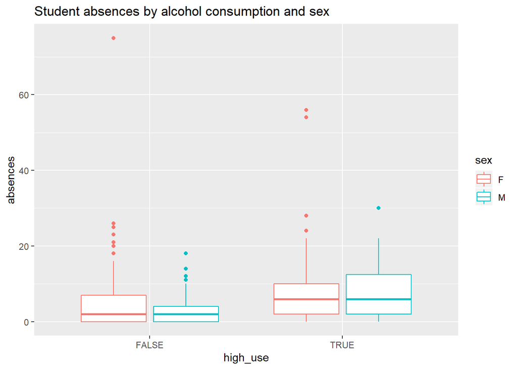

```r
library(ggplot2)
g <- ggplot(alc, aes(x = high_use, y = absences, col = sex))
g + geom_boxplot() + ylab("absences") + ggtitle("Student absences by alcohol consumption and sex")
```

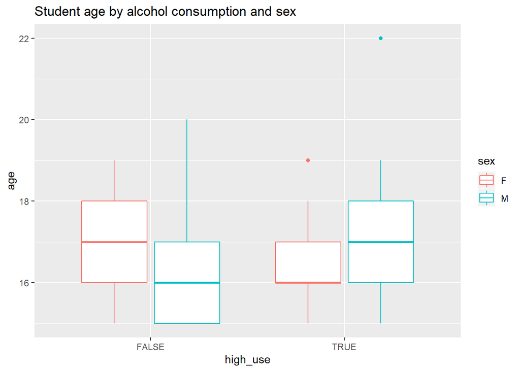

```r
g <- ggplot(alc, aes(x = high_use, y = age, col = sex))
g + geom_boxplot() + ylab("age") + ggtitle("Student age by alcohol consumption and sex")
```

- cross table

```r
select(alc, high_use, failures, absences, sex, age) %>% tail(10)
```

```
##     high_use failures absences sex age
## 373    FALSE        1        0   M  19
## 374     TRUE        1       14   M  18
## 375    FALSE        0        2   F  18
## 376    FALSE        0        7   F  18
## 377    FALSE        1        0   F  19
## 378    FALSE        0        0   F  18
## 379    FALSE        1        0   F  18
## 380    FALSE        1        0   F  18
## 381     TRUE        0        3   M  17
## 382     TRUE        0        0   M  18
```

```r
table(high_use = alc$high_use, failures = alc$failures)
```

```
##         failures
## high_use   0   1   2   3
##    FALSE 234  22   5   9
##    TRUE   82  16   6   8
```

```r
table(high_use = alc$high_use, absences = alc$absences)
```

```
##         absences
## high_use  0  1  2  3  4  5  6  7  8  9 10 11 12 13 14 15 16 17 18 19 20 21
##    FALSE 94  2 54  2 36  4 19  6 13  3 12  1  6  0  7  1  2  0  2  0  1  1
##    TRUE  22  1 13  4 15  0 11  2  8  0  5  1  4  3  4  2  4  1  2  1  1  0
##         absences
## high_use 22 23 24 25 26 28 30 54 56 75
##    FALSE  0  1  0  1  1  0  0  0  0  1
##    TRUE   3  0  1  0  0  1  1  1  1  0
```

```r
table(high_use = alc$high_use, sex = alc$sex)
```

```
##         sex
## high_use   F   M
##    FALSE 157 113
##    TRUE   41  71
```

```r
table(high_use = alc$high_use, age = alc$age)
```

```
##         age
## high_use 15 16 17 18 19 20 22
##    FALSE 63 79 65 55  7  1  0
##    TRUE  18 28 35 26  4  0  1
```